# Multi Armed Bandit

Faathir Chikal Asyuraa & Tansa Qurrota A’yuna

1/28/2020

# 1 Pengenalan *Multi-Armed Bandit*

## 1.1 Permasalahan yang diberikan

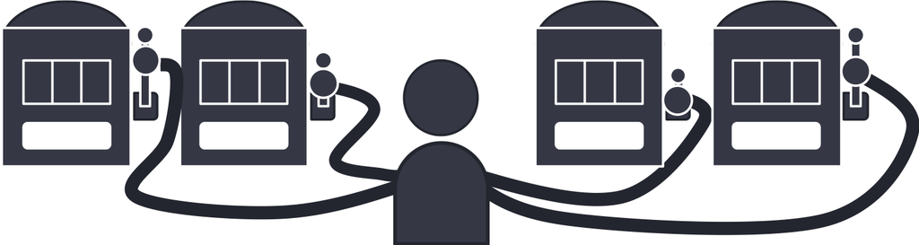

Permasalahan *Multi-Armed Bandit* berfokus pada bagaimana kita dapat memaksimalkan keuntungan dan menemukan pilihan yang memberikan kita keuntungan paling besar dari sekumpulan pilihan yang ada.

Pada permasalahan *Multi-Armed Bandit* ini, seberapa besar keuntungan yang dihasilkan dari melakukan sebuah pilihan tidak diketahui secara pasti. Ibarat bermain judi pada slot machine, kita tidak akan tau seberapa besar peluang kita mendapatkan keuntungan.

## 1.2 Eksploitasi vs Eksplorasi

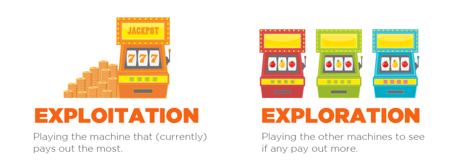

Jika kita hanya terus mencoba pilihan yang kelihatannya sudah baik (eksploitasi), kita mungkin akan melewatkan opsi opsi baru yang mungkin ternyata lebih menguntungkan.

Sedangkan, jika kita hanya terus mencoba coba pilihan yang ada (eksplorasi), kita dapat saja membuang buang sumber daya yang seharusnya dapat di alokasikan pada pilihan yang lebih baik.

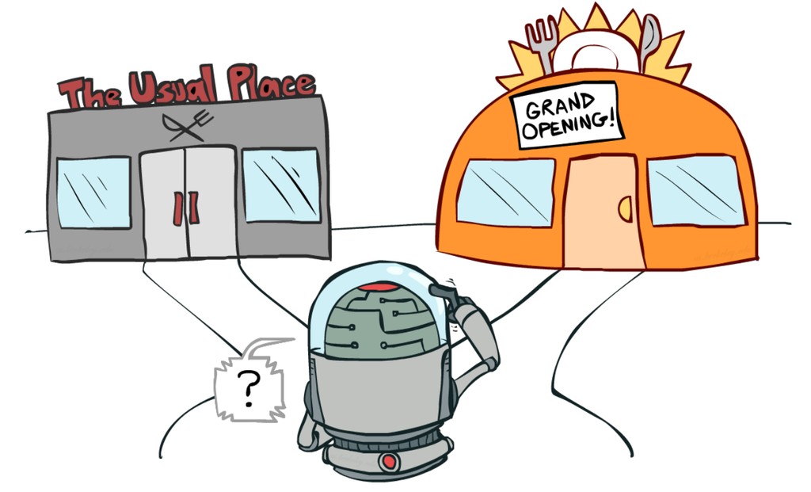

Dilema yang diberikan adalah, bagaimana caranya kita menyeimbangkan antara eksploitasi dengan eksplorasi tersebut.

[figure not shown]

## 1.3 Contoh Aplikasi Multi-Armed Bandit

- Ketika ingin mencari tempat makan, lebih baik pergi ke restoran langganan atau coba restoran baru?
- Dalam website berita, lebih baik menempatkan berita populer atau berita yang baru pada halaman depan?
- Dalam pengembangan website, lebih baik mencoba citravisual yang baru atau tetap menggunakan citravisual yang sudah teruji
- Dalam mengiklankan produk, tipe iklan yang seperti apa yang akan menghasilkan calon pembeli/pengguna yang paling banyak?
- Dalam uji klinis, lebih baik mencoba obat yang sudah lama teruji atau bereksperimen dengan obat obat baru?

## 1.4 Istilah dasar yang digunakan

- [Reward] Seberapa besar *keuntungan* yang dihasilkan
- [Arm] Pilihan yang ada
- [Bandit] Himpunan dari pilihan-pilihan yang ada
- [Play / Trial] Siklus penarikan *arm* dan melihat yang dihasilkan
- [Regret] Berapa besar perbedaan reward yang didapat andaikan saja kita memilih *arm* yang optimal
- [Horizon] Berapa banyak *trial* yang dapat dilakukan
- [Exploration] Mencoba *arm* yang baru
- [Exploitation] Mencoba *arm* yang **diketahui** memiliki *reward* yang tinggi
- [Policy] Kebijakan pemilihan *arm* pada setiap *trial*-nya

## 1.5 Famili *Multi-Armed Bandit*

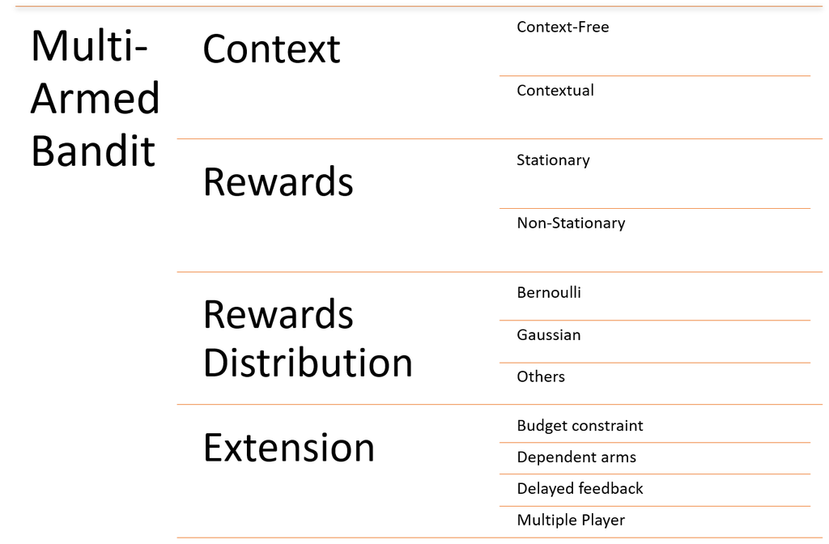

## 1.6 Cara Kerja *Multi-Armed Bandit*

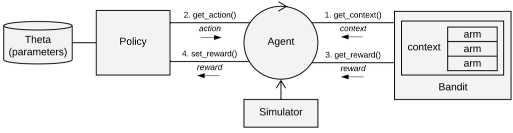

## 1.7 Catatan mengenai *Multi-Armed Bandit*

*Multi-Armed Bandit* berada pada cabang *Reinforcement Learning* pada ranah *Data Science*. *Multi-Armed Bandit* tidak menerima input data seperti model *Supervised Learning* dan *Unsupervised Learning* pada umumnya, melainkan Multi-Armed Bandit meminta data / mengambil keputusan apa yang seharusnya diambil, informasi harus dikumpulkan secara bertahap, dan pengambilan keputusan itu pun akan berubah ubah secara dinamis seiring penelitian berjalan

## 1.8 *Library* yang digunakan

```r
library(contextual)
```

# 2 Simulasi Bernoulli Bandit

## 2.1 Penjelasan Bernoulli Bandit

Jenis Bandit dapat menentukan bagaimana reward diberikan, beberapa jenis bandit dapat dilihat pada famili *Multi-Armed Bandit*.

Pada Simulasi pertama, akan ditampilkan Bernoulli Bandit, dimana reward yang diberikan berdistribusi Bernoulli, yaitu reward berupa 0 atau 1, dengan probabilitas mendapatkan reward 1 adalah sebesar Θ

## 2.2 Inisialisasi Bernoulli Bandit

Akan dibuat Bernoulli Bandit dengan menspesifikasikan probabilitas *reward* pada tiap *arm*, Serta menentukan seberapa banyak penarikan *arm* yang tersedia.

Pada simulasi ini akan dibuat 3 *arm*, dengan distribusi masing masing *arm* nya adalah bernoulli dengan peluang mendapatkan reward adalah:

- [*Arm* 1] 75%
- [*Arm* 2] 50%
- [*Arm* 3] 25%

Akan dilakukan 200 penarikan *arm*, serta simulasi ini akan diulang 100 kali untuk meminimalisir efek random dalam melihat performa simulasi.

```r
bernoulli_bandit <- ContextualBernoulliBandit$new(matrix(c(0.75, 0.5, 0.25), 1))
simulations = 100
horizon = 200
```

## 2.3 Menentukan *Policy*

*Policy* adalah kebijakan dalam pemilihan *arm*, akan dicoba beberapa policy yang cukup umum.

### 2.3.1 *Epsilon First* (*A/B Testing*)

Pada *policy* ini, akan dilakukan eksplorasi dulu pada beberapa periode, yaitu penarikan *arm* akan dilakukan secara acak selama sekian periode, lalu setelah periode eksplorasi selesai, akan dilanjutkan dengan periode eksploitasi dengan memilih *arm* yang dianggap memiliki probabilitas *reward* yang paling tinggi.

Pada simulasi ini akan dilakukan periode eksplorasi sebesar 60% dari total percobaan, yaitu 120 percobaan akan di alokasikan untuk eksplorasi, dan 80 percobaan akan dialokasikan untuk eksploitasi

```r
ef_policy <- EpsilonFirstPolicy$new(epsilon = 0.6,
                                    N = horizon)
```

### 2.3.2 *Epsilon Greedy*

Pada *policy* ini, eksplorasi akan dilakukan dengan probabilitas ε dan eksploitasi akan dilakukan dengan probailitas 1 - ε, besarnya ε akan mempengaruhi seberapa sering kita melakukan eksplorasi

Pada simulasi ini, akan ditentukan ε = 10%

```r
eg_policy <- EpsilonGreedyPolicy$new(0.1)
```

### 2.3.3 *SoftMax*

Pada *policy* ini, probabilitas pemilihan *arm* akan proporsional dengan *cumulative reward* yang didapat. *Softmax Policy* memiliki *temperature* parameter τ, yang menentukan seberapa banyak *arm* yang dapat kita eksplor, ketika τ bernilai kecil, *arm* yang memiliki reward yang lebih tinggi akan lebih cenderung dipilih, sedangkan jika τ bernilai besar, semua *arm* memiliki kesempatan yang sama untuk di eksplor.

```r
softmax_policy <- SoftmaxPolicy$new(tau = 0.1)
```

### 2.3.4 *Upper Confidence Bound*

Pada *policy* ini, probabilitas pemilihan *arm* tidak hanya proporsional dengan *cumulative reward* yang dihasilkan, namun juga berdasarkan seberapa sering kita menarik menarik suatu *arm*. Algoritma ini menerapkan konsep optimis karena arm yang jarang ditarik akan diberi insentif lebih untuk dicoba di eksplor karena dianggap informasi yang dikumpulkan belum terlalu banyak.

```r
ucb_policy <- UCB1Policy$new()
```

### 2.3.5 Thompson Sampling

Karena bandit yang digunakan adalah Bernoulli, dapat ditentukan prior pada mean dari reward pada setiap *arm*, Thompson Sampling menggunakan model beta-binomial, dengan parameter yang digunakan adalah alfa dan beta dalam mengatur distribusi beta.

Pada simulasi ini akan digunakan prior uniform (beta(1,1)).

```r
ts_policy <- ThompsonSamplingPolicy$new(alpha = 1,
                                        beta = 1)
```

## 2.4 Menjalankan simulasi

### 2.4.1 Mengumpulkan *policy-policy* yang dibuat pada satu *agent*

```r
agents <- list(Agent$new(ef_policy,
                         bernoulli_bandit),
               Agent$new(eg_policy,
                         bernoulli_bandit),
               Agent$new(softmax_policy,
                         bernoulli_bandit),
               Agent$new(ucb_policy,
                         bernoulli_bandit),
               Agent$new(ts_policy,
                         bernoulli_bandit))
```

### 2.4.2 Mengesekusi simulasi

```r
simulator <- Simulator$new(agents,
                           horizon,
                           simulations,
                           do_parallel = TRUE)
history <- simulator$run()
```

# 3 Hasil Simulasi

## 3.1 Mendapatkan penamaan agent

*Agent* yang digunakan akan mengacu berdasarkan nama fungsi *policy* yang digunakan, untuk mengetahui penamaan yang diberikan, dapat dilakukan

```r
history$get_agent_list()
```

```
## [1] "EpsilonFirst"     "EpsilonGreedy"    "Softmax"
## [4] "UCB1"             "ThompsonSampling"
```

## 3.2 *History* pemilihan *arm*

Berikut akan disajikan *arm* mana yang dipilih pada setiap *trial* yang ada, perlu diingat bahwa peluang mendapatkan reward untuk tiap arm adalah

- [*Arm* 1] 75%
- [*Arm* 2] 50%
- [*Arm* 3] 25%

### 3.2.1 *Epsilon First* (*A/B Testing*)

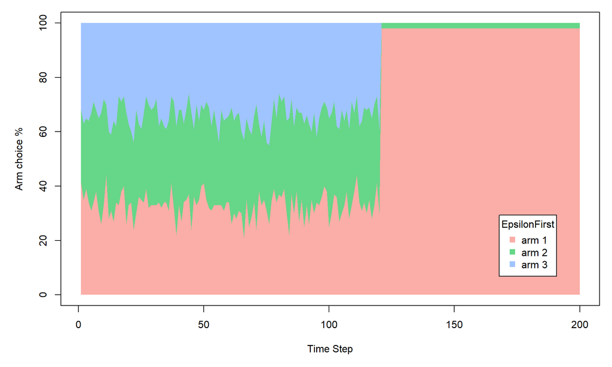

```r
plot(history,
     type = "arms",
     limit_agents = "EpsilonFirst")
```

### 3.2.2 *Epsilon Greedy*

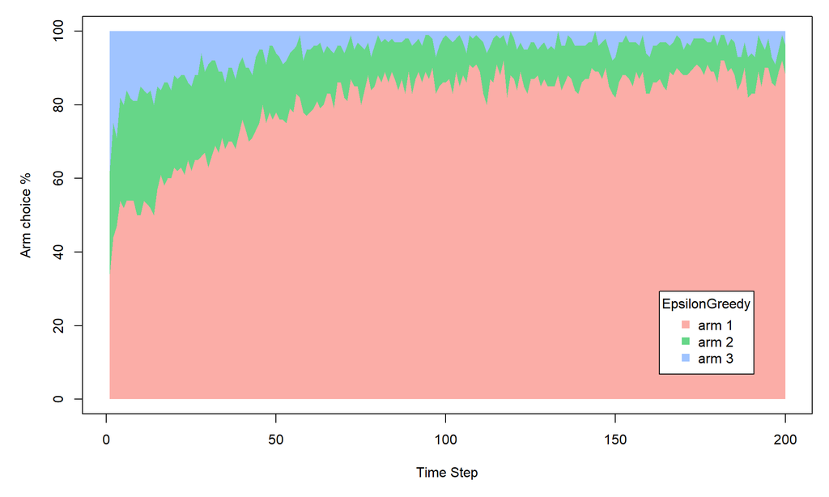

```r
plot(history,
     type = "arms",
     limit_agents = "EpsilonGreedy")
```

### 3.2.3 *Softmax*

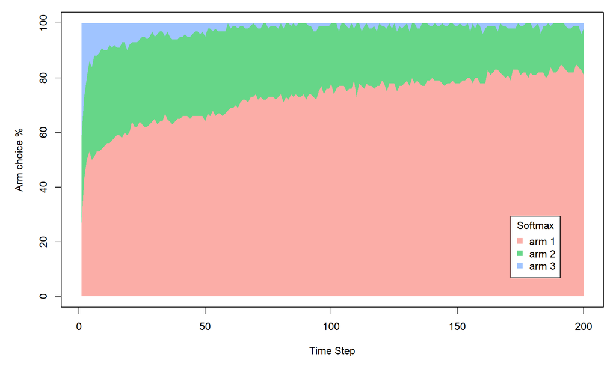

```r
plot(history,
     type = "arms",
     limit_agents = "Softmax")
```

### 3.2.4 *Upper Confidence Bounds*

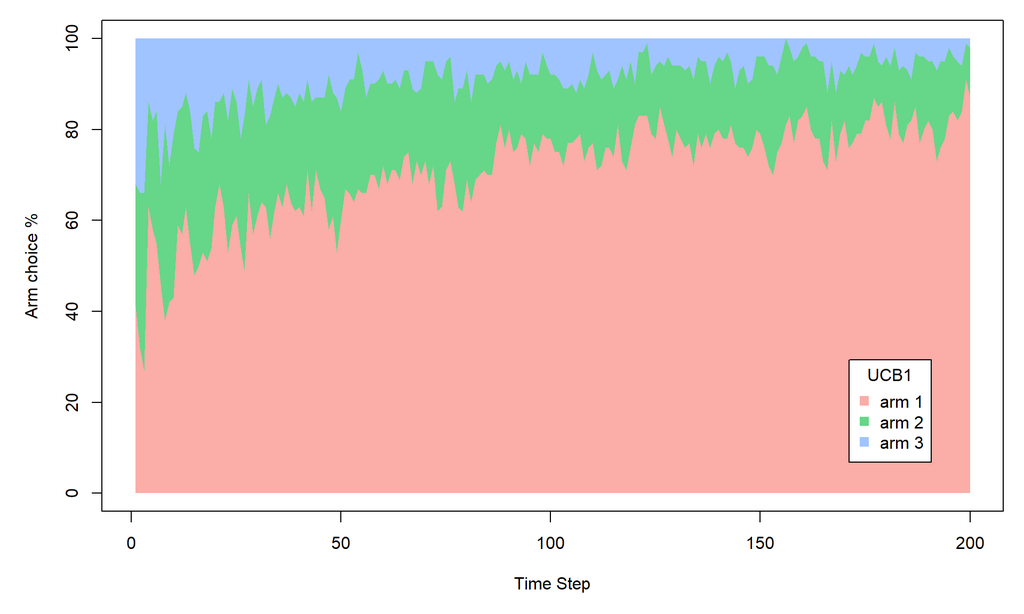

```r
plot(history,
     type = "arms",
     limit_agents = "UCB1")
```

### 3.2.5 Thompson Sampling

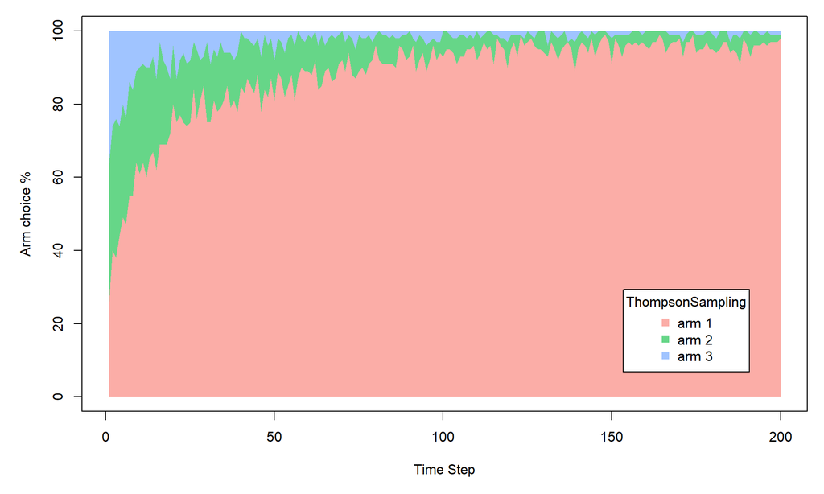

```r
plot(history,
     type = "arms",
     limit_agents = "ThompsonSampling")
```